# Bellabeat Case Study: How Can A Wellness Technology Company Play It Smart?

### 4.2.3 Use of smart device - By Time Worn per Day

We need to create a new data frame calculating the total amount of minutes users wore the device every day and creating three different categories:

- All day - device was worn all day.
- More than half day - device was worn more than half of the day.
- Less than half day - device was worn less than half of the day.

```python
# Create new column 'Percentage' of Hours used Fitbit Tracker
merged_df['TotalHoursPercentage'] = round(merged_df['TotalHours'] / 24 * 100,2)

# Define function for classifying 'Worn' based on 'TotalHoursPercentage'
def w(row):
    if row['TotalHoursPercentage'] < 50:
        val = 'Less than half day'
    elif row['TotalHoursPercentage'] < 100:
        val = 'More than half day'
    else:
        val = 'All Day'
    return val

# Create new column 'Worn' using the function above
merged_df['Worn'] = merged_df.apply(w, axis = 1)

# View DataFrame
hourly_use = merged_df[['Id','Date','TotalHours','TotalHoursPercentage','Worn']]
hourly_use
```

|  | Id | Date | TotalHours | TotalHoursPercentage | Worn |
| --- | --- | --- | --- | --- | --- |
| 0 | 1503960366 | 2016-04-12 | 18.23 | 75.96 | More than half day |
| 1 | 1503960366 | 2016-04-13 | 17.22 | 71.75 | More than half day |
| 2 | 1503960366 | 2016-04-14 | 24.00 | 100.00 | All Day |
| 3 | 1503960366 | 2016-04-15 | 16.63 | 69.29 | More than half day |
| 4 | 1503960366 | 2016-04-16 | 17.33 | 72.21 | More than half day |
| ... | ... | ... | ... | ... | ... |
| 935 | 8877689391 | 2016-05-08 | 24.00 | 100.00 | All Day |
| 936 | 8877689391 | 2016-05-09 | 24.00 | 100.00 | All Day |
| 937 | 8877689391 | 2016-05-10 | 24.00 | 100.00 | All Day |
| 938 | 8877689391 | 2016-05-11 | 24.00 | 100.00 | All Day |
| 939 | 8877689391 | 2016-05-12 | 15.52 | 64.67 | More than half day |

940 rows × 5 columns

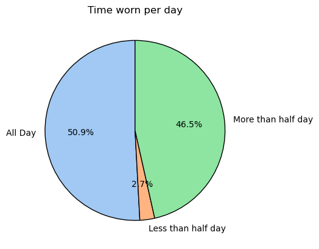

```python
# Plot Hourly Usage Pie Chart
worn_count = hourly_use.groupby(['Worn']).count()['Date'].reset_index()

plt.pie(x = worn_count['Date'],
        labels = worn_count['Worn'],
        colors = sns.color_palette('pastel'),
        wedgeprops = {"edgecolor": "black"},
        autopct='%1.1f%%', startangle = 90)
plt.title('Time worn per day')
plt.show()
```

## 4.3 Correlations

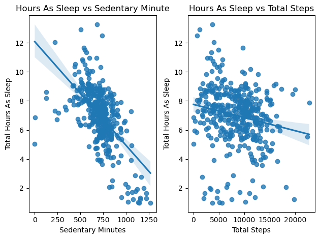

```python
# Create two subplots
fig, (ax1, ax2) = plt.subplots(ncols=2)

#Plot 'Hours As Sleep vs Sedentary Minute' & 'Hours As Sleep vs Total Steps'
sns.regplot(x=merged_df['SedentaryMinutes'],
            y=merged_df['TotalHoursAsSleep'],
            ax=ax1)
sns.regplot(x=merged_df['TotalSteps'],
            y=merged_df['TotalHoursAsSleep'],
            ax=ax2)

ax1.set(title='Hours As Sleep vs Sedentary Minute', xlabel= 'Sedentary Minutes', ylabel = 'Total Hours As Sleep')
ax2.set(title='Hours As Sleep vs Total Steps', xlabel= 'Total Steps', ylabel = 'Total Hours As Sleep')

plt.tight_layout()
```

From the plots above:

- We can see the negative relationship between Sedentary Minutes and Sleep time. ( *Note: This relationship is weak and still need more data to support as correlation between some data doesn’t mean causation*)
- There is no correlation between daily activity level based on steps and the amount of hours users sleep a day.

# STEP 5: ACT

In the final step, we will be delivering our insights and providing recommendations based on our analysis.

Here, we revisit our business questions and share with you our high-level business recommendations.

## 1. What are the trends identified?

### 1.3 Correlations

- There is a negative relationship between Sedentary Minutes and Sleep time, which means that higher Sedentary minutes might result in less sleep time.

## 2. How could these trends apply to Bellabeat customers?

Both FitBit and Bellabeat develop products focused on providing women with their health, habit and fitness data and encouraging them to understand their current habits and make healthy decisions. These common trends surrounding health and fitness can very well applied to Bellabeat customers.

## 3. How could these trends help influence Bellabeat marketing strategy?

### 3.1 Bellabeat's target audience

These women do some light activity to stay healthy (according to the activity type analysis). Even though they need to improve their everyday activity to have health benefits. They might need some knowledge about developing healthy habits or motivation to keep going.

### 3.2 Recommendations for Bellabeat app

**1. Create a Reflect Section:** This section provides users with insights about their fitness level & how they are compared to the average or the fitness goals they have set. Hence, they could be encouraged to become more active to achieve their health & fitness goal. From these users personal insights, the app can propose health knowledge related to the user insights. For example, propose the different benefits of walking more than 7,000, 8,000 and 10,000 steps a day when users daily steps are below 7,000.

**2. Create an Exercise Section:** Suggest different types of exercise for different purpose (ie. simple 10 minutes exercise on weekday and a more intense exercise on weekends, relaxing exercise to enhance sleep, meditation, etc.) and calories intake and burnt rate information on the Bellabeat app.

**3. Gamification:**

- Make users fitness goals into game levels with rewards to motivate users to do active activities instead of sedentary activities (ie. Daily/weekly/ monthly calorie burning challenge, Daily steps of 7,000-10,000 steps challenge, Follow the Exercise Plan in Exercise Section, etc.).
- Reward: Using 'Streak' like Duolingo streak to motivate users (Note: A streak starts at zero and increases by one for each day the user completes a lesson. It resets to zero if the user does not complete a challenge). Reaching certain milestones (such as 100 day streak) can earn the user discounts voucher on other Bellabeat products or health-related products (i.e tumbler, yoga mat, etc.)

**4. Notification:**

- Send push notification to remind users to go for a walk or do a short exercise at lunch time & after working hours.
- User could set up a desired time to go to sleep and receive a notification minutes before to prepare to sleep. Also offer helpfull resources to help customers sleep - ex. breathing advises, podcasts with relaxing music, sleep techniques.

- Water-resistant
- Long-lasting batteries so that users can wear the products everyday to any occasion without worrying about the battery.
- Fashion/ elegant products as the target audience are women

Thank you for your interest to my Bellabeat Case Study!